# Projeto e Análise de Experimento com Helicópteros de Papel: Avaliação de Fatores e Variabilidade

Eduardo Demetrio | Gustavo Lima | João Moro | Vitor Zambaldi

Data de execução do experimento: 07/05/2025

## Questão 1

Descreva a unidade experimental.

**Resposta:**

No contexto do experimento, a unidade experimental é **um helicóptero de papel**.

## Questão 2

Defina os conceitos de réplicas e duplicatas. Explique a diferença entre réplicas e duplicatas para esta situação.

**Resposta:**

##### **Réplicas**

- Réplicas são **repetições independentes de um mesmo tratamento** em diferentes unidades experimentais. O objetivo das réplicas é estimar a variabilidade experimental e melhorar a precisão da comparação entre tratamentos.

##### **Duplicatas**

- Duplicatas, por outro lado, são **medidas repetidas na mesma unidade experimental** ou condições idênticas, sem alteração entre as execuções. Elas são usadas para verificar a repetibilidade do sistema de medição e não para estimar a variabilidade do processo.

##### **Diferença entre Réplicas e Duplicatas neste experimento com helicópteros de papel:**

- **Réplicas**: moldar e lançar vários helicópteros diferentes com o mesmo comprimento de asa, cronometrando o tempo de voo de cada um. Assim, há variação natural entre as unidades (helicópteros) mesmo sob o mesmo tratamento, o que permite avaliar a variabilidade experimental.
- **Duplicatas** : lançar **o mesmo helicóptero duas vezes seguidas sob as mesmas condições** e medir o tempo de voo em ambas as ocasiões. Isso não ajuda a estimar a variabilidade entre unidades experimentais, mas sim a verificar se o sistema de medição (cronômetro, operador, ambiente) é consistente.

Para este estudo, o ideal é trabalhar com réplicas e não duplicatas, pois o interesse está em avaliar como diferentes comprimentos de asa afetam o tempo de voo em unidades experimentais.

## Questão 3

Descreva o fator de tratamento.

**Resposta:**  
O fator de tratamento é o **comprimento da asa dos helicópteros de papel** .

Esse fator possui quatro níveis :

- 4,00 polegadas
- 4,75 polegadas
- 5,50 polegadas
- 6,00 polegadas

Cada nível corresponde a um comprimento específico das asas dos helicópteros, sendo aplicado durante a confecção de cada unidade experimental.

O objetivo do experimento é investigar se o comprimento da asa (fator de tratamento) influencia significativamente o tempo de voo dos helicópteros.

## Questão 4

Descreva quaisquer variáveis ocultas que possam afetar os resultados dos experimentos.

**Resposta:**  
Variáveis ocultas são aquelas variáveis que não fazem parte do projeto experimental, mas que podem influenciar a variável de resposta, com um aumento de viés ou na variação não captada pela modelagem. Alguns exemplos de variáveis ocultas no experimento: vento durante o lançamento / Altura de lançamento / Forma de lançamento

## Questão 5

Explique por que a randomização seria importante.

**Resposta:**  
A randomização é uma técnica que consiste em **aleatorizar a ordem de aplicação dos tratamentos nas unidades experimentais**.

##### **Importância da randomização:**

- **Elimina ou reduz o efeito de variáveis ocultas**: ao aleatorizar a ordem dos lançamentos e a atribuição dos tratamentos, diminui-se a chance de que fatores não controlados (como correntes de ar, cansaço do operador ou variações na altura de lançamento) afetem sistematicamente determinados tratamentos.
- **Garante independência das observações**: ao randomizar, asseguramos que os resultados de uma unidade experimental não influenciem os resultados de outra.

##### **No contexto deste experimento:**

Deve-se randomizar a ordem dos lançamentos dos helicópteros com diferentes comprimentos de asa. Assim, por exemplo, não se corre o risco de lançar todos os helicópteros de 6” seguidos que poderiam coincidir com fator de variável oculta momentâneo que poderia distorcer os resultados.

## Questão 6

Crie uma lista aleatória de experimentos para examinar quatro comprimentos de asa de 4”,4,75”, 5,5” e 6” com oito experimentos replicados em cada nível.

**Esses são nossos dados estruturais dos helicópteros criados para o experimento:**

| tratamento | tamanho base | Tamanho dobra | tamanho asa | Dobra 1 | Dobra 2 | Largura |
| --- | --- | --- | --- | --- | --- | --- |
| H1 | 10 | 2 | 18 | 3.921568627 | 1.633986928 | 10.7 |
| H2 | 12 | 2 | 16 | 4.705882353 | 1.960784314 | 10.7 |
| H3 | 14 | 2 | 14 | 5.490196078 | 2.287581699 | 10.7 |
| H4 | 15.3 | 2 | 12.7 | 6 | 2.5 | 10.7 |

**Esses são os dados dos lançamentos realizados aleatórios:**

| Experimento | Tratamento |
| --- | --- |
| 1 | H2 (4.75”) |
| 2 | H3 (5.5”) |
| 3 | H1 (4”) |
| 4 | H1 (4”) |
| 5 | H4 (6”) |
| 6 | H4 (6”) |
| 7 | H3 (5.5”) |
| 8 | H4 (6”) |
| 9 | H4 (6”) |
| 10 | H4 (6”) |
| 11 | H2 (4.75”) |
| 12 | H2 (4.75”) |
| 13 | H2 (4.75”) |
| 14 | H1 (4”) |
| 15 | H3 (5.5”) |
| 16 | H3 (5.5”) |
| 17 | H1 (4”) |
| 18 | H1 (4”) |
| 19 | H2 (4.75”) |
| 20 | H3 (5.5”) |

## Questão 7

Realize os experimentos e colete os dados.

**Esses são os dados finais do experimento:**

| Experimento | Tratamento | Tempo (s) |
| --- | --- | --- |
| 1 | H2 (4.75”) | 3.87 |
| 2 | H3 (5.5”) | 3.40 |
| 3 | H1 (4”) | 4.89 |
| 4 | H1 (4”) | 3.98 |
| 5 | H4 (6”) | 2.77 |
| 6 | H4 (6”) | 3.10 |
| 7 | H3 (5.5”) | 3.07 |
| 8 | H4 (6”) | 3.18 |
| 9 | H4 (6”) | 2.65 |
| 10 | H4 (6”) | 2.82 |
| 11 | H2 (4.75”) | 4.27 |
| 12 | H2 (4.75”) | 4.22 |
| 13 | H2 (4.75”) | 3.53 |
| 14 | H1 (4”) | 3.68 |
| 15 | H3 (5.5”) | 3.46 |
| 16 | H3 (5.5”) | 3.40 |
| 17 | H1 (4”) | 4.42 |
| 18 | H1 (4”) | 3.43 |
| 19 | H2 (4.75”) | 3.60 |
| 20 | H3 (5.5”) | 3.13 |

## Questão 8

Realize uma análise de variancia com seus dados.

**Com base no resultado da tabela ANOVA, considerando um teste de hipótese em que H0 corresponde à afirmação de que não há diferença significativa no tempo de voo em função das diferentes medidas, e H1 indica que pelo menos uma medida resulta em um tempo de voo distinto, podemos concluir que, ao nível de significância de 5%, há evidências significativas para rejeitar H0. Pelo menos uma das medidas apresenta diferença significativa em relação às demais.**

|  | Df | Sum Sq | Mean Sq | F value | Pr(>F) |
| --- | --- | --- | --- | --- | --- |
| **tratamento** | 3 | 4.429 | 1.4762 | 10.92 | 0.000377 *** |
| **Residuals** | 16 | 2.162 | 0.1352 |  |  |

|  | diff | lwr | upr | p adj |
| --- | --- | --- | --- | --- |
| **H2-H1** | -0.182 | -0.8472225 | 0.48322249 | 0.8611532 |
| **H3-H1** | -0.788 | -1.4532225 | -0.12277751 | 0.0176812 |
| **H4-H1** | -1.176 | -1.8412225 | -0.51077751 | 0.0006080 |
| **H3-H2** | -0.606 | -1.2712225 | 0.05922249 | 0.0807552 |
| **H4-H2** | -0.994 | -1.6592225 | -0.32877751 | 0.0029274 |
| **H4-H3** | -0.388 | -1.0532225 | 0.27722249 | 0.3710739 |

## Questão 9

Verifique as premissas de igualdade de variancia e normalidade com gráficos residuais

**Histograma dos Residuos:**

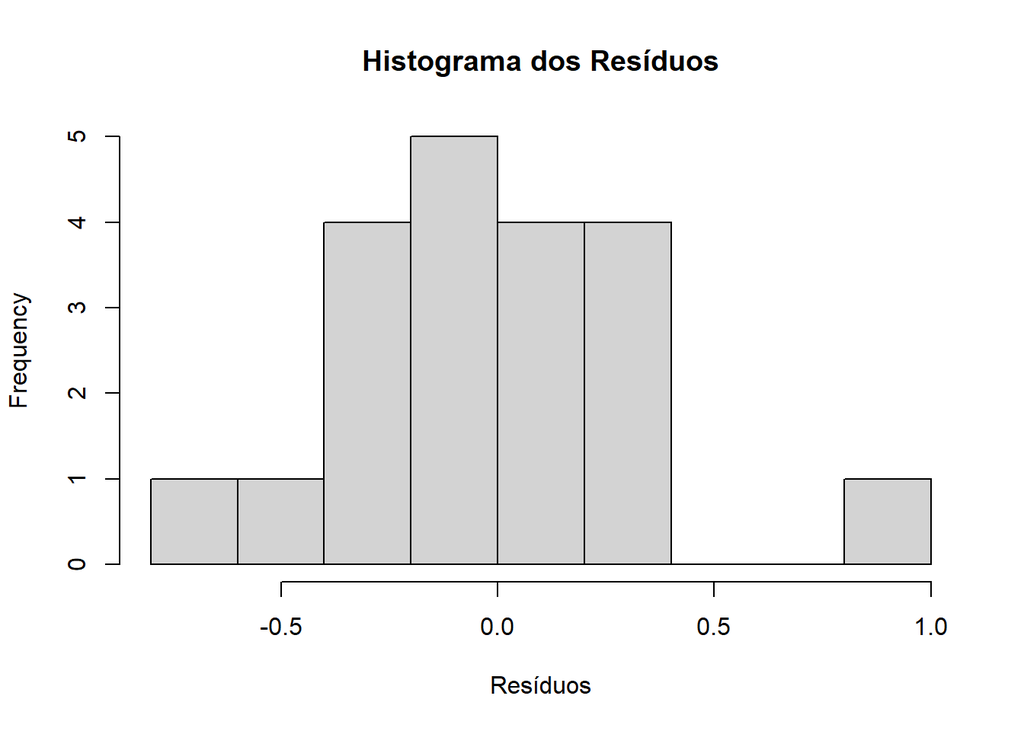

**Verificando normalidade com QQ Plot**

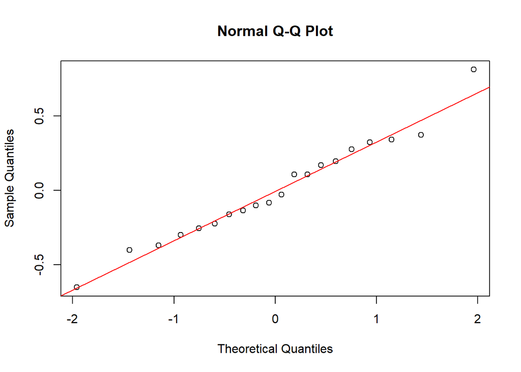

**Teste Shapiro-Wilk para normalidade**

```
##
##  Shapiro-Wilk normality test
##
## data:  residuos
## W = 0.97925, p-value = 0.9241
```

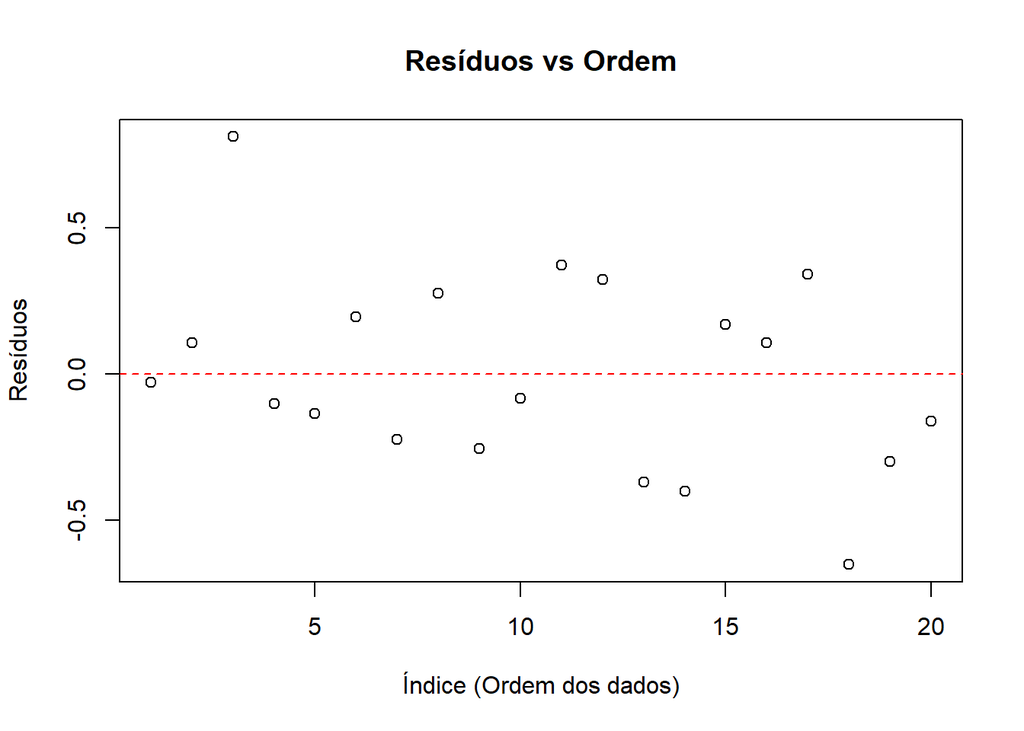

**Teste de homogeneidade de variâncias (Teste de Bartlett)**

```
##
##  Bartlett test of homogeneity of variances
##
## data:  tempo by tratamento
## Bartlett's K-squared = 5.9503, df = 3, p-value = 0.1141
```